# Czynniki wpływające na czas rozwiązywania zadań z matematyki PISA 2015 - etap 1

### Porównanie wyników

Spośród dwóch rozpatrzonych rodzajów transformacji musimy wybrać jedną. W tym celu porównamy ich wykresy QQ:

**Optymalna transformacja Boxa-Coxa**

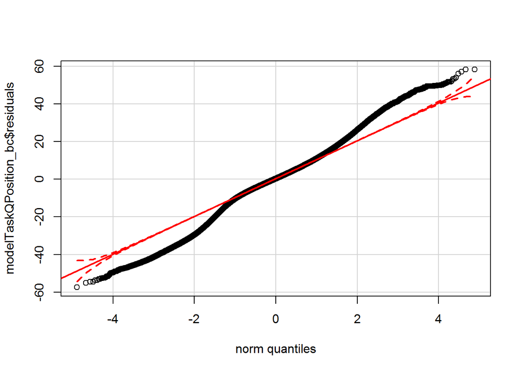

```r
modelTaskQPosition_bc <- lm(time^wykladnik ~ task + task/Q.nb + position, data = sample_data)
qqPlot(modelTaskQPosition_bc$residuals)
```

```r
aic_bc <- AIC(modelTaskQPosition_bc, k = 2)
rm(modelTaskQPosition_bc)
```

**Optymalna transformacja logarytmiczna z przesunięciem**

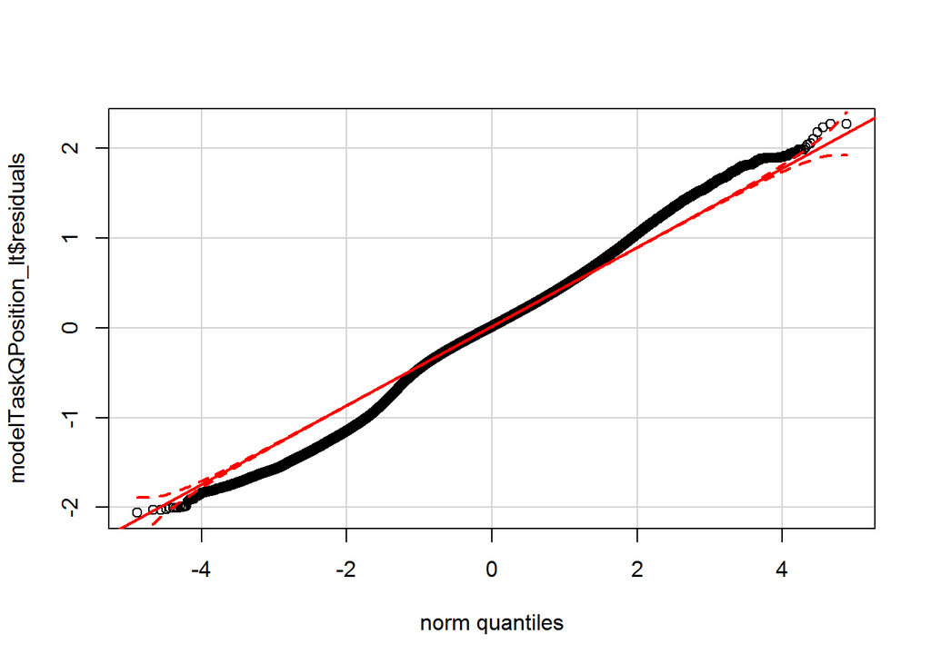

```r
modelTaskQPosition_lt <- lm(log(time + przesuniecie) ~ task + task/Q.nb + position, data = sample_data)
qqPlot(modelTaskQPosition_lt$residuals)
```

```r
aic_lt <- AIC(modelTaskQPosition_lt, k = 2)
rm(modelTaskQPosition_lt)
```

Na podstawie powyższych wykresów stwierdzamy, że żadna z transformacji nie rozwiązuje problemu nienormalności reszt. Wielkość rozbieżności jest podobna dla obu transformacji, jednak wydaje się dotyczyć mniejszej liczby kwantyli w przypadku transformacji logarytmicznej z przesunięciem. Ponadto, kryterium informacyjne Akaike’a wynosi 7.591477810^{6} dla pierwszego modelu, a 1.441145410^{6} dla drugiego, czyli wyraźnie wskazuje na drugi z nich (podobnie jest z kryterium bayesowskim Schwarza). Z tego względu decydujemy się na transformację logarytmiczną z przesunięciem 2.878837910^{4}.

### Zależności pomiędzy zmienną objaśnianą i objaśniającymi

Przed budową modelu warto zastanowić się nad sensownością włączenia do niego poszczególnych zmiennych. W tym celu przyjrzymy się bliżej rozkładowi zmiennej objaśnianej w podziale na grupy ze względu na wartości kolejnych zmiennych objaśniających (wszystkie są jakościowe, stąd podział na grupy).

Na wszystkich wykresach na niebiesko zaznaczamy globalną średnią zmiennej objaśnianej, a na czerwono średnią w grupach.

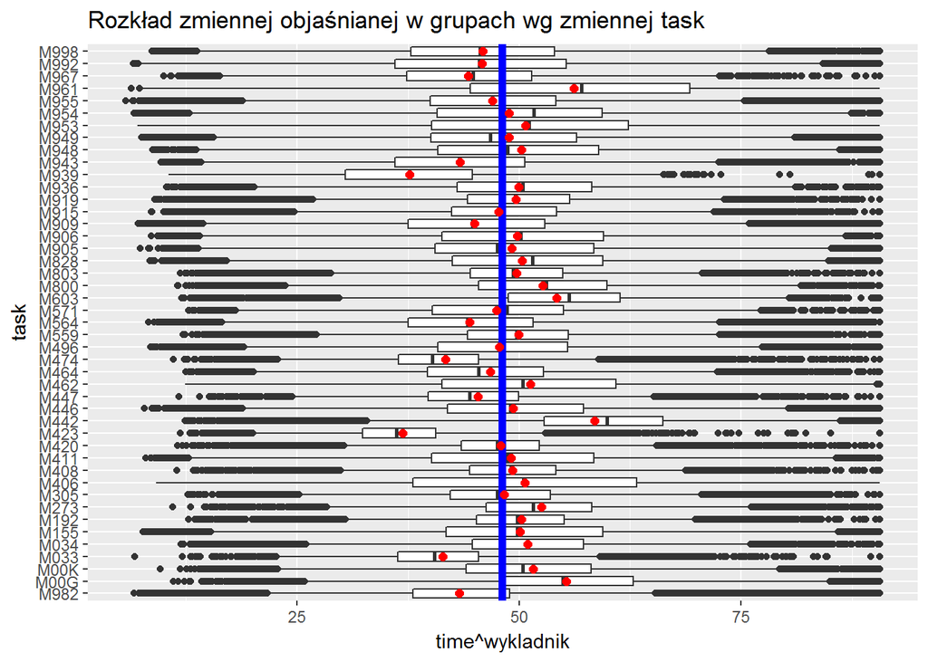

```r
ggplot(sample_data, aes(y = time^wykladnik, x = task)) + geom_boxplot() + geom_hline(aes(yintercept = mean(sample_data$time^wykladnik)), color = "blue", size = 2) + coord_flip() + stat_summary(fun.y = mean, shape = 16, color = 'red', size = 2, geom = 'point') + ggtitle("Rozkład zmiennej objaśnianej w grupach wg zmiennej task")
```

Na powyższym wykresie widzimy, że występuje wyraźne zróżnicowanie rozkładu (a przede wszystkim jego średniej) zmiennej objaśnianej w zależności od rozwiązywanego zadania, czego można się było spodziewać biorąc pod uwagę to, że zadania różnią się od siebie trudnością itp.

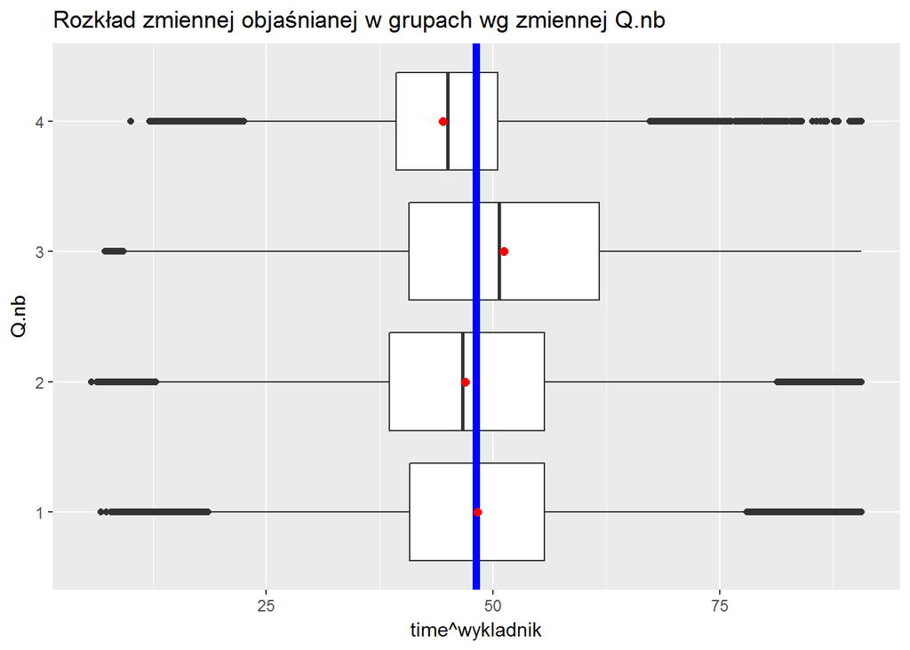

```r
ggplot(sample_data, aes(y = time^wykladnik, x = Q.nb)) + geom_boxplot() + geom_hline(aes(yintercept = mean(sample_data$time^wykladnik)), color = "blue", size = 2) + coord_flip() + stat_summary(fun.y = mean, shape = 16, color = 'red', size = 2, geom = 'point') + ggtitle("Rozkład zmiennej objaśnianej w grupach wg zmiennej Q.nb")
```

Na powyższym wykresie widzimy, że zróżnicowanie rozkładu zmiennej objaśnianej w zależności od (skorygowanego) numeru podpunktu nie jest zbyt duże. Możemy zatem wstępnie podejrzewać, że nie występuje zjawisko znudzenia/zmęczenia zadaniem ani wzrostu trudności kolejnych podpunktów.

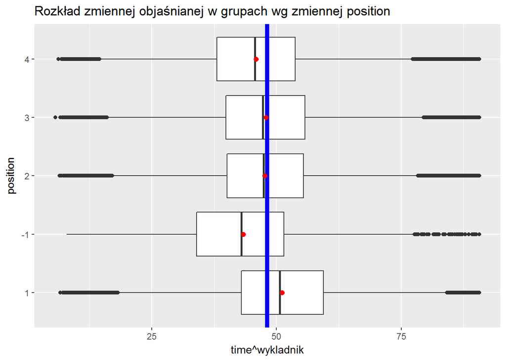

```r
ggplot(sample_data, aes(y = time^wykladnik, x = position)) + geom_boxplot() + geom_hline(aes(yintercept = mean(sample_data$time^wykladnik)), color = "blue", size = 2) + coord_flip() + stat_summary(fun.y = mean, shape = 16, color = 'red', size = 2, geom = 'point') + ggtitle("Rozkład zmiennej objaśnianej w grupach wg zmiennej position")
```

Na powyższym wykresie widzimy, że zróżnicowanie rozkładu zmiennej objaśnianej w zależności od pozycji zadania w kwestionariuszu przejawia się przesunięciem tego rozkładu w stronę niższych wartości w przypadku pozycji -1, która może oznaczać coś nietypowego (takich obserwacji jest zaledwie 16 tysięcy w całym zbiorze wobec prawie miliona w przypadku pozostałych wartości tej zmiennej) – `BOOKID` dla wszystkich obserwacji, dla których `position == -1` przyjmuje wartość `rm` zamiast liczby, jak we wszystkich pozostałych przypadkach.

Podsumowując, spodziewamy się istotności wszystkich zmiennych objaśniających, przy czym najważniejsza wydaje się być zmienna `task`, więc włączymy ją do modelu jako pierwszą, co będzie szczególnie ważne przy analizie wariancji (zbadamy oczywiście alternatywne warianty).

## Budowa modelu

### Sekwencyjne testy istotności zmiennych

Pierwszym krokiem przy budowie modelu liniowego jest wybór zmiennych objaśniających. Na tym etapie analizy naszym zadaniem jest rozpatrzenie trzech zmiennych jako objaśniających: zadanie, podpunkt i pozycja w kwestionariuszu. Należy jednak zastanowić się w jakiej postaci do modelu powinna wejść zmienna podpunkt. Włączenie jej jako osobnej zmiennej będzie oznaczało, że kolejność podpunktów ma znaczenie dla czasu ich rozwiązywania. Z drugiej strony, moglibyśmy włączyć podpunkt jako zmienną zagnieżdżoną w zadaniu, co odzwierciedlałoby zróżnicowanie podpunktów w zadaniach, niekoniecznie związane z ich kolejnością.

Poniżej szacujemy parametry w obu wersjach:

```r
modelTaskQPosition <- lm(log(time + przesuniecie) ~ task + Q.nb + position, data = sample_data)
aic1 <- AIC(modelTaskQPosition, k = 2); bic1 <- BIC(modelTaskQPosition)
anova(modelTaskQPosition)
```

```
## Analysis of Variance Table
##
## Response: log(time + przesuniecie)
##               Df Sum Sq Mean Sq F value    Pr(>F)
## task          44  21847  496.52  1786.4 < 2.2e-16 ***
## Q.nb           3   3464 1154.72  4154.4 < 2.2e-16 ***
## position       4   6154 1538.57  5535.4 < 2.2e-16 ***
## Residuals 961662 267296    0.28
## ---
## Signif. codes:  0 '***' 0.001 '**' 0.01 '*' 0.05 '.' 0.1 ' ' 1
```

```r
modelTaskQPosition <- lm(log(time + przesuniecie) ~ task + task:Q.nb + position, data = sample_data)
aic2 <- AIC(modelTaskQPosition, k = 2); bic2 <- BIC(modelTaskQPosition)
anova(modelTaskQPosition)
```

```
## Analysis of Variance Table
##
## Response: log(time + przesuniecie)
##               Df Sum Sq Mean Sq F value    Pr(>F)
## task          44  21847  496.52  1895.2 < 2.2e-16 ***
## position       4   6157 1539.31  5875.5 < 2.2e-16 ***
## task:Q.nb     37  18820  508.66  1941.5 < 2.2e-16 ***
## Residuals 961628 251936    0.26
## ---
## Signif. codes:  0 '***' 0.001 '**' 0.01 '*' 0.05 '.' 0.1 ' ' 1
```

W obu modelach wszystkie zmienne są isototne przy dowolnym sensownym poziomie istotności. Kryterium informacyjne Akaike’a wynosi 1.497990310^{6} dla pierwszego i 1.441145410^{6} dla drugiego modelu, a bayesowskie Schwarza 1.498614510^{6} i 1.442169910^{6}, odpowiednio. Oba kryteria przyjmują niższe wartości dla modelu z interakcją, zatem ten model będziemy rozważać w dalszej analizie.

Teraz przeprowadzimy sekwencyjne testy łącznej istotności zmiennych rozpatrując pozostałe możliwe kolejności włączania tych zmiennych do modelu:

```r
anova(lm(log(time + przesuniecie) ~ task:Q.nb + task + position, data = sample_data))
```

```
## Analysis of Variance Table
##
## Response: log(time + przesuniecie)
##               Df Sum Sq Mean Sq F value    Pr(>F)
## task          44  21847  496.52  1895.2 < 2.2e-16 ***
## position       4   6157 1539.31  5875.5 < 2.2e-16 ***
## task:Q.nb     37  18820  508.66  1941.5 < 2.2e-16 ***
## Residuals 961628 251936    0.26
## ---
## Signif. codes:  0 '***' 0.001 '**' 0.01 '*' 0.05 '.' 0.1 ' ' 1
```

```r
anova(lm(log(time + przesuniecie) ~ position + task + task:Q.nb, data = sample_data))
```

```
## Analysis of Variance Table
##
## Response: log(time + przesuniecie)
##               Df Sum Sq Mean Sq F value    Pr(>F)
## position       4   6250 1562.39  5963.6 < 2.2e-16 ***
## task          44  21755  494.42  1887.2 < 2.2e-16 ***
## task:Q.nb     37  18820  508.66  1941.5 < 2.2e-16 ***
## Residuals 961628 251936    0.26
## ---
## Signif. codes:  0 '***' 0.001 '**' 0.01 '*' 0.05 '.' 0.1 ' ' 1
```

```r
anova(lm(log(time + przesuniecie) ~ task + position + task:Q.nb, data = sample_data))
```

```
## Analysis of Variance Table
##
## Response: log(time + przesuniecie)
##               Df Sum Sq Mean Sq F value    Pr(>F)
## task          44  21847  496.52  1895.2 < 2.2e-16 ***
## position       4   6157 1539.31  5875.5 < 2.2e-16 ***
## task:Q.nb     37  18820  508.66  1941.5 < 2.2e-16 ***
## Residuals 961628 251936    0.26
## ---
## Signif. codes:  0 '***' 0.001 '**' 0.01 '*' 0.05 '.' 0.1 ' ' 1
```

```r
anova(lm(log(time + przesuniecie) ~ task:Q.nb + position + task, data = sample_data))
```

```
## Analysis of Variance Table
##
## Response: log(time + przesuniecie)
##               Df Sum Sq Mean Sq F value    Pr(>F)
## position       4   6250 1562.39  5963.6 < 2.2e-16 ***
## task          44  21755  494.42  1887.2 < 2.2e-16 ***
## task:Q.nb     37  18820  508.66  1941.5 < 2.2e-16 ***
## Residuals 961628 251936    0.26
## ---
## Signif. codes:  0 '***' 0.001 '**' 0.01 '*' 0.05 '.' 0.1 ' ' 1
```

```r
anova(lm(log(time + przesuniecie) ~ position + task:Q.nb + task, data = sample_data))
```

```
## Analysis of Variance Table
##
## Response: log(time + przesuniecie)
##               Df Sum Sq Mean Sq F value    Pr(>F)
## position       4   6250 1562.39  5963.6 < 2.2e-16 ***
## task          44  21755  494.42  1887.2 < 2.2e-16 ***
## task:Q.nb     37  18820  508.66  1941.5 < 2.2e-16 ***
## Residuals 961628 251936    0.26
## ---
## Signif. codes:  0 '***' 0.001 '**' 0.01 '*' 0.05 '.' 0.1 ' ' 1
```

**Wniosek:** Na podstawie powyższych wyników stwierdzamy, że przy każdym rozsądnym poziomie istotności odrzucamy hipotezę zerową, że model bez jednej ze zmiennych jest lepszy niż model z nią, niezależnie od kolejności włączania zmiennych do modelu. Oznacza to, że wszystkie zmienne są ważne i powinny zostać w modelu.

### Oszacowania parametrów

Oszacowania parametrów naszego modelu są następujące:

```r
summary(modelTaskQPosition)
```

```
##
## Call:
## lm(formula = log(time + przesuniecie) ~ task + task:Q.nb + position,
##     data = sample_data)
##
## Residuals:
##      Min       1Q   Median       3Q      Max
## -2.05934 -0.28082  0.01458  0.31227  2.26611
##
## Coefficients: (98 not defined because of singularities)
##                 Estimate Std. Error  t value Pr(>|t|)
## (Intercept)    11.510166   0.004445 2589.192  < 2e-16 ***
## taskM00G        0.500370   0.006171   81.083  < 2e-16 ***
## taskM00K        0.341428   0.006203   55.045  < 2e-16 ***
## taskM033       -0.096537   0.006158  -15.676  < 2e-16 ***
## taskM034        0.318791   0.006229   51.182  < 2e-16 ***
## taskM155        0.033858   0.006163    5.494 3.94e-08 ***
## taskM192        0.291626   0.006166   47.294  < 2e-16 ***
## taskM273        0.384190   0.006157   62.401  < 2e-16 ***
## taskM305        0.205648   0.006155   33.410  < 2e-16 ***
## taskM406        0.450440   0.006174   72.961  < 2e-16 ***
## taskM408        0.247558   0.006159   40.194  < 2e-16 ***
## taskM411        0.536191   0.006182   86.741  < 2e-16 ***
## taskM420        0.192150   0.006162   31.183  < 2e-16 ***
## taskM423       -0.290518   0.006162  -47.148  < 2e-16 ***
## taskM442        0.631381   0.006205  101.758  < 2e-16 ***
## taskM446        0.138640   0.006164   22.491  < 2e-16 ***
## taskM447        0.078044   0.006154   12.681  < 2e-16 ***
## taskM462        0.321658   0.006220   51.717  < 2e-16 ***
## taskM464        0.135173   0.006192   21.829  < 2e-16 ***
## taskM474       -0.083646   0.006159  -13.581  < 2e-16 ***
## taskM496        0.204254   0.006157   33.175  < 2e-16 ***
## taskM559        0.274616   0.006173   44.489  < 2e-16 ***
## taskM564       -0.002433   0.006203   -0.392 0.694854
## taskM571        0.169718   0.006194   27.399  < 2e-16 ***
## taskM603        0.456217   0.006188   73.726  < 2e-16 ***
## taskM800        0.389414   0.006204   62.765  < 2e-16 ***
## taskM803        0.266211   0.006192   42.993  < 2e-16 ***
## taskM828        0.399674   0.006180   64.676  < 2e-16 ***
## taskM905       -0.022734   0.006558   -3.466 0.000527 ***
```

[output cut: 146 more lines]

```
## taskM948:Q.nb4        NA         NA       NA       NA
## taskM949:Q.nb4        NA         NA       NA       NA
## taskM953:Q.nb4        NA         NA       NA       NA
## taskM954:Q.nb4        NA         NA       NA       NA
## taskM955:Q.nb4        NA         NA       NA       NA
## taskM961:Q.nb4        NA         NA       NA       NA
## taskM967:Q.nb4        NA         NA       NA       NA
## taskM992:Q.nb4        NA         NA       NA       NA
## taskM998:Q.nb4        NA         NA       NA       NA
## ---
## Signif. codes:  0 '***' 0.001 '**' 0.01 '*' 0.05 '.' 0.1 ' ' 1
##
## Residual standard error: 0.5118 on 961628 degrees of freedom
## Multiple R-squared:  0.1567, Adjusted R-squared:  0.1567
## F-statistic:  2103 on 85 and 961628 DF,  p-value: < 2.2e-16
```

```r
rm(modelTaskQPosition)
```

### Testy post-hoc

Następnym krokiem w naszej analizie jest wykonanie testów post-hoc.

#### Test t

Po wykonaniu testów $t$ porównujących średnie parami dla kazdej ze zmiennych objaśniających stwierdzamy, że przy poziomie istotności 0.05 różnice między średnimi są nieistotne dla:

- **zmienna task:** średni czas rozwiązywania nie różni się zbytnio pomiędzy niektórymi parami zadań (w pełnej tabeli p-wartości zdarzają się nawet wartości 1), jednak jest ich mniejszość (wszystkich par jest 990). Poniższa tabela obrazuje pary zadań, pomiędzy którymi różnice są nieistotne:

```r
df1 <- pairwise.t.test(log(sample_data$time + przesuniecie), sample_data$task)$p.value
df <- as.data.frame(which(df1 > 0.05, arr.ind = TRUE))
df$col <- factor(df$col, levels = 1:length(colnames(df1)), labels = colnames(df1))
df$row <- factor(df$row, levels = 1:length(colnames(df1)), labels = colnames(df1))
rownames(df) <- 1:nrow(df)
t(df) # wiersze row i col dają pary, dla których różnice sa nieistotne
```

```
##     1      2      3      4      5      6      7      8      9      10
## row "M939" "M955" "M033" "M447" "M464" "M447" "M949" "M155" "M496" "M800"
## col "M982" "M00G" "M00K" "M00K" "M033" "M034" "M034" "M155" "M155" "M155"
##     11     12     13     14     15     16     17     18     19     20
## row "M803" "M905" "M919" "M943" "M305" "M496" "M803" "M919" "M943" "M949"
## col "M155" "M155" "M155" "M155" "M192" "M192" "M192" "M192" "M192" "M192"
##     21     22     23     24     25     26     27     28     29     30
## row "M603" "M411" "M948" "M803" "M919" "M943" "M949" "M408" "M442" "M800"
## col "M273" "M305" "M305" "M406" "M406" "M406" "M406" "M408" "M408" "M408"
##     31     32     33     34     35     36     37     38     39     40
## row "M828" "M915" "M953" "M442" "M828" "M953" "M474" "M909" "M800" "M828"
## col "M408" "M408" "M408" "M411" "M411" "M411" "M420" "M420" "M446" "M446"
##     41     42     43     44     45     46     47     48     49     50
## row "M915" "M953" "M906" "M949" "M954" "M564" "M909" "M800" "M803" "M905"
## col "M446" "M446" "M447" "M462" "M464" "M496" "M496" "M559" "M559" "M559"
##     51     52     53     54     55     56     57     58     59     60
## row "M915" "M919" "M943" "M961" "M909" "M954" "M905" "M915" "M919" "M943"
## col "M559" "M559" "M559" "M564" "M571" "M571" "M803" "M803" "M803" "M803"
##     61     62     63     64     65     66     67     68     69     70
## row "M919" "M943" "M953" "M915" "M919" "M943" "M919" "M943" "M943" "M992"
## col "M828" "M828" "M905" "M906" "M906" "M906" "M919" "M919" "M936" "M992"
```

- **zmienna Q.nb:** wszystkie podpunkty różnią się istotnie pod względem średniego czasu rozwiązywania zadania

```r
pairwise.t.test(log(sample_data$time + przesuniecie), sample_data$Q.nb)$p.value
```

```
##   1             2  3
## 2 0            NA NA
## 3 0  0.000000e+00 NA
## 4 0 2.387178e-194  0
```

- **zmienna position:** wszystkie pozycje w kwestionariuszu różnią się istotnie pod względem średniego czasu rozwiązywania zadania

```r
pairwise.t.test(log(sample_data$time + przesuniecie), sample_data$position)$p.value
```

```
##                1           -1            2  3
## -1 8.229831e-285           NA           NA NA
## 2   0.000000e+00 1.290430e-89           NA NA
## 3   0.000000e+00 1.281832e-96 6.443629e-06 NA
## 4   0.000000e+00 1.065421e-32 0.000000e+00  0
```

#### Test Tukey’a

Następnie wykonamy test post-hoc Tukey’a. Niestety, ze względu na liczbę parametrów związanych z zagnieżdżoną interakcją zmiennej `task` ze zmienną `Q.nb` posiadana przez nas moc obliczeniowa nie pozwala na wykonanie tego testu dla naszego modelu, dlatego wykonujemy go dla modelu ze zmienną `Q.nb` bez interakcji, co jest pewnym uproszczeniem.

```r
print(plot(TukeyHSD(aov(log(time + przesuniecie) ~ task + Q.nb + position, data = sample_data), which = "task"), las = 1))
```

Na poniższym wykresie widzimy wyniki testu Tukey’a dla zmiennej `task` (dalsze wydłużanie tego wykresu niewiele pomaga, dlatego zostawiliśmy go w tej postaci). Widać, że różnice między niektórymi zadaniami jest nieistotna, ale jest ich zdecydowanie mniej niż istotnych różnic (przedziały ufności są bardzo wąskie ze względu na dużą liczbę obserwacji).

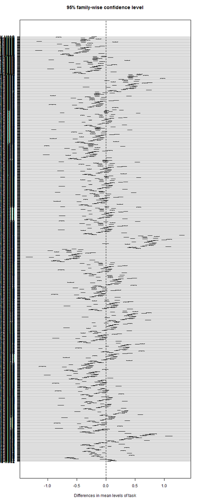

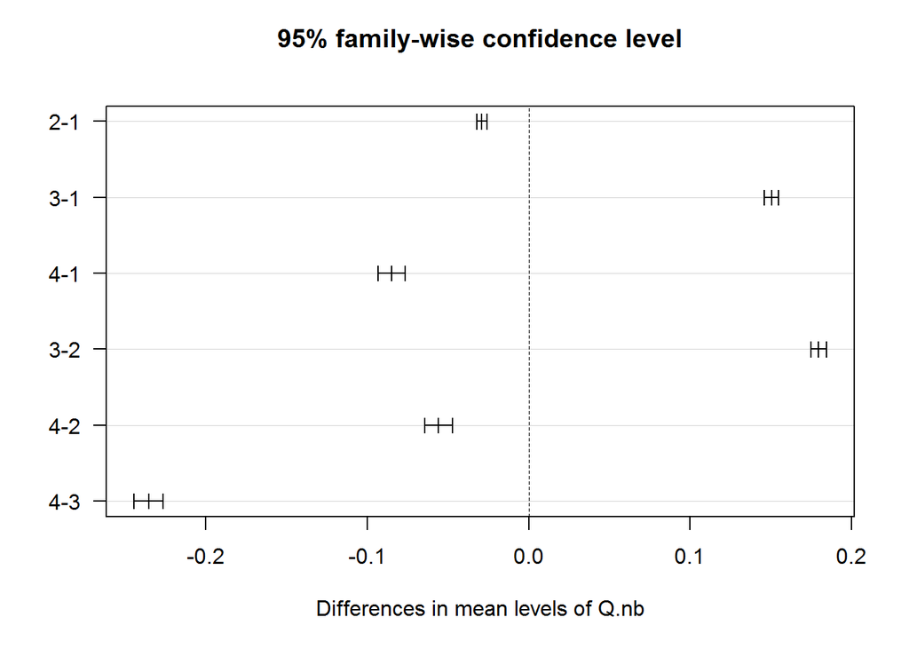

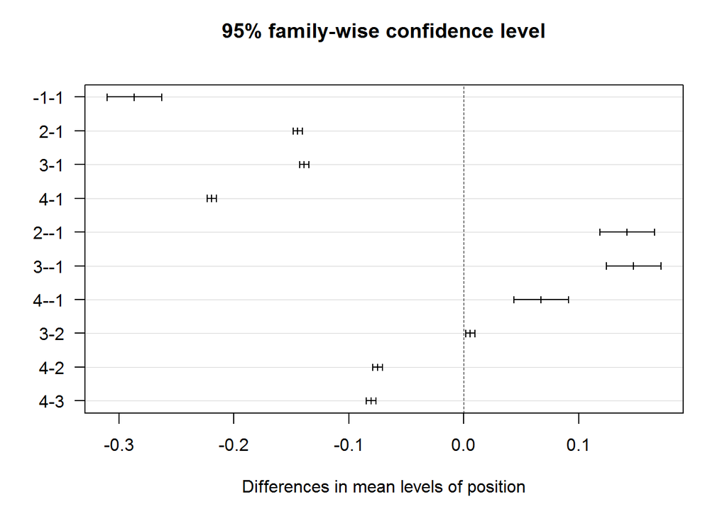

```r
plot(TukeyHSD(aov(log(time + przesuniecie) ~ task + Q.nb + position, data = sample_data), which = c("Q.nb", "position")), las = 1)
```

Na obu poniższych wykresach widać, że przy poziomie istotności 0.05 wszystkie pary kategorii każdej ze zmiennych `Q.nb` i `position` różnią się pomiędzy sobą.

## Wnioski

Na tym etapie analizy stwierdzamy, że przy tym zestawie rozważanych zmiennych objaśniających wszystkie są istotne w objaśnianiu zmienności czasu rozwiązywania zadania.

Optymalną dla naszego modelu transformacją zmiennej objaśnianej jest transformacja logarytmiczna po przesunięciu, przy czym należy pamiętać, że analizę wykonujemy na podpróbce zbioru danych wybierając co czwartą szkołę.

Testy post-hoc wskazują na istotne różnice między średnimi czasami rozwiązywania zadań po transformacji między większością grup obserwacji ze względu na kategorie wybranej zmiennej objaśnianej.

# Załączniki

Podczas analizy nienormalności rozkładu reszt natrafiliśmy na zróżnicowanie kształtu rozkładu zmiennej objaśnianej w podziale na grupy ze względu na zadanie, co prezentujemy poniżej:

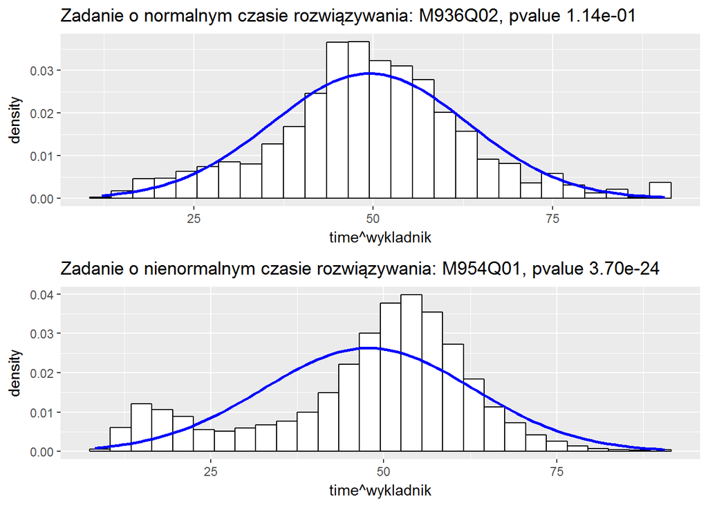

```r
normal.task <- sample_data[sample_data$item_short == "M936Q02", ]
nonnormal.task <- sample_data[sample_data$item_short == "M954Q01", ]
normal.plot <- ggplot(normal.task, aes(x = time^wykladnik)) + geom_histogram(aes(y=..density..), binwidth = 3, color = "black", fill = "white") + stat_function(fun = dnorm, args = list(mean = mean(normal.task$time^wykladnik), sd = sd(normal.task$time^wykladnik)), color = "blue", size = 1) + ggtitle("Zadanie o normalnym czasie rozwiązywania: M936Q02, pvalue 1.14e-01")
nonnormal.plot <- ggplot(nonnormal.task, aes(x=time^wykladnik)) + geom_histogram(aes(y=..density..), binwidth = 3, color = "black", fill = "white") + stat_function(fun = dnorm, args = list(mean = mean(nonnormal.task$time^wykladnik), sd = sd(nonnormal.task$time^wykladnik)), color = "blue", size = 1) + ggtitle("Zadanie o nienormalnym czasie rozwiązywania: M954Q01, pvalue 3.70e-24")
grid.arrange(normal.plot, nonnormal.plot)
```

Nienormalność rozkładów jest na ogół powodowana wysoką kurtozą – rozkłady są zbyt spiczaste jak na rozkład normalny o parametrach estymowanych z danych. Ponadto, z wykresów widać że w wielu zadaniach populacja jest bardzo niejednorodna. Poza wspomnianymi już wcześniej uczniami “wytrwałymi”, powodującymi długie ogony, w niektorych zadaniach widać również wyraźnie populację “geniuszy”, którzy rozwiązują zadania o wiele szybciej. Histogramy wskazują że populację “geniuszy” również cechuje normalny czas rozwiązywania zadania.

Rozkład empiryczny jest najprawdopodobniej mieszanką trzech rozkładów, w tym dwóch rozkładów normalnych odpowiadających “geniuszom” i uczniom “typowym”, oraz nieznanego rozkładu dla uczniów “wytrwałych”. Można przypuszczać, ze po wyodrębnieniu poszczególnych populacji np. algorytmem EM, otrzymalibyśmy po transformacji Boxa-Coxa normalne czasy rozwiązywania zadań.